# Clase 8: Pesca industrial y Espacios Costeros Marinos de Pueblos Originarios (ECMPO)

## Paso 12 | Intersectar lances con ECMPO y con el anillo externo

**Tip**

**C) Intersecar lances con ECMPO.** Ahora realizaremos **dos intersecciones** para identificar:

- Lances que ocurrieron **dentro** de ECMPO decretadas.
- Lances que ocurrieron en el **anillo externo** (5 km alrededor).

### Intersección 1 — Lances dentro de ECMPO

**33.** Ve al menú superior y haz clic en **Vectorial → Herramientas de geoproceso → Intersección**.

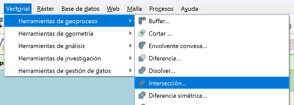

Menú Vectorial > Herramientas de geoproceso > Intersección.

**34.** Configura los parámetros:

- **Capa de entrada:** `lances_chile_ZEE` (la capa de lances ya filtrada dentro de la ZEE)
- **Capa superpuesta:** `ecmpo_decretadas` (la capa filtrada que contiene solo ECMPO oficialmente decretadas)

Haz clic en **Ejecutar**.

[figure not shown]

Configuración de la Intersección 1.

**35.** Como se realizó en el paso N°32, para mantener el orden de tus capas, modifica el nombre de la intersección generada a `Lances_dentro_ECMPO`.

**Nota**

**PAUSA** — debería verse así:

[figure not shown]

QGIS generará una nueva capa que contiene **solo los lances que intersectan espacialmente con las ECMPO**.

### Intersección 2 — Lances en el anillo de 5 km

**36.** Ve al menú superior y haz clic en **Vectorial → Herramientas de geoproceso → Intersección**.

**37.** Configura los parámetros:

- **Capa de entrada:** `lances_chile_ZEE`
- **Capa superpuesta:** `anillo_externo_ecmpo` (el anillo de 5 km, sin solapamientos)

[figure not shown]

Configuración de la Intersección 2.

**38.** Como se realizó en el paso N°35, para mantener el orden de tus capas, modifica el nombre al proceso generado a `lances_borde_ecmpo`.

## Paso 13 | Clasificar los lances por zona (Dentro vs. Borde)

**Tip**

**D) Clasificar lances por zona y periodo.** En esta sección agregaremos dos campos a las capas resultantes de las intersecciones para construir mapas temáticos que comparan la actividad pesquera **antes y después del decreto**, **dentro y fuera** de las ECMPO.

### En la capa `Lances_dentro_ECMPO`

**39.** Haz clic derecho sobre la capa `Lances_dentro_ECMPO` → **Abrir tabla de atributos**. Posteriormente, abre la **Calculadora de Campos**.

[figure not shown]

Abrir la Calculadora de Campos sobre Lances_dentro_ECMPO.

**40.** Configura lo siguiente:

- Marca la opción **“Crear un campo nuevo”**
- **Nombre del campo:** `zona`
- **Tipo de campo:** Texto (cadena)

Escribe esta expresión: `'Dentro'`

Click en **Aceptar**.

[figure not shown]

Calculadora de Campos: crear campo zona con valor ‘Dentro’.

### En la capa `lances_borde_ecmpo`

**41.** Haz clic derecho sobre la capa `lances_borde_ecmpo` → **Abrir tabla de atributos**. Posteriormente, abre la **Calculadora de Campos**.

**42.** Configura lo siguiente:

- Marca la opción **“Crear un campo nuevo”**
- **Nombre del campo:** `zona`
- **Tipo de campo:** Texto (cadena)

Escribe esta expresión: `'Borde'`

Click en **Aceptar**.

[figure not shown]

Calculadora de Campos: crear campo zona con valor ‘Borde’.

**43.** En **ambas capas guarden los cambios efectuados**. Esto te permitirá distinguir espacialmente los lances según si ocurrieron dentro del ECMPO o en su borde inmediato.

## Paso 14 | Clasificar los lances por periodo (Antes vs. Después)

**44.** En **ambas capas**, abre la tabla de atributos y, posteriormente, la **Calculadora de Campos**.

**45.** En la Calculadora de Campos:

- Marca **“Crear un campo nuevo”**
- **Nombre del campo:** `periodo`
- **Tipo de campo:** Texto (cadena)

Expresión:

```
CASE
  WHEN "RECALADA" < "dateDecree" THEN 'Antes'
  ELSE 'Después'
END
```

[figure not shown]

Calculadora de Campos: crear campo periodo con la expresión CASE.

**46.** En **ambas capas guarden los cambios efectuados**.

**Tip**

Con este campo cada lance queda marcado como ocurrido **Antes** o **Después** del decreto de la ECMPO en la que cae — esa es la base para comparar los dos mapas que vienen.

## Paso 15 | Mapa 1 — Actividad pesquera *antes* del decreto

**Tip**

**ETAPA 4 — Visualización final mediante dos mapas comparativos.** En esta guía nos centraremos en la **Región del Biobío y sus ECMPO**, pero para el portafolio pueden elegir un ECMPO a elección.

**Objetivo de los mapas:** Visualizar la dinámica espacial de la pesca industrial en torno a las ECMPO decretadas, comparando la situación **antes y después del decreto**, distinguiendo si los lances ocurrieron **dentro** o en el **borde** (anillo externo de 5 km sin solapamientos).

**Mapa 1** — Este mapa muestra los lances ocurridos **antes de que la ECMPO fuera decretada**, indicando si ocurrieron **dentro de la zona que luego sería ECMPO** o en su borde.

**47.** En ambas capas `Lances_dentro_ECMPO` y `lances_borde_ecmpo`, ve a **Propiedad → Fuentes → Constructor de consultas**.

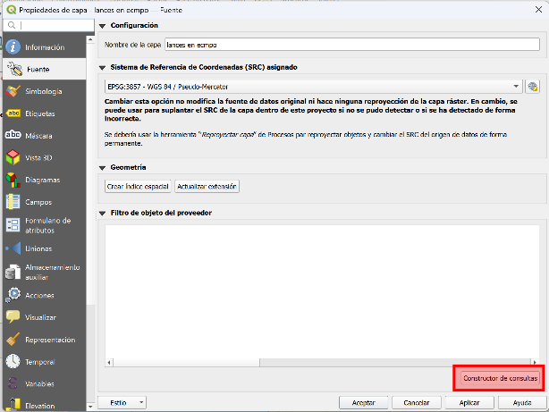

Acceder al Constructor de consultas desde las propiedades de la capa.

**48.** Escriba la siguiente expresión para filtrar:

```
"periodo" = 'Antes'
```

Click en **Aceptar** en ambas pestañas.

[figure not shown]

Constructor de consultas con el filtro periodo = ‘Antes’.

**49.** En ambas capas: `Lances_dentro_ECMPO` y `lances_borde_ecmpo`, como se ha hecho en clases anteriores anda a **Propiedades → Simbología**; asigna **un color distinto a cada capa** para que se distingan visualmente en los mapas:

- Capa `Lances_dentro_ECMPO` → simbología en **azul (o verde)**. Representa los lances industriales que ocurrieron **dentro** de las ECMPO.
- Capa `lances_borde_ecmpo` → simbología en **naranja (o rojo)**. Representa los lances industriales que ocurrieron en el **borde** (anillo externo de 5 km).

**Nota**

**PAUSA** — debería visualizarse algo así:

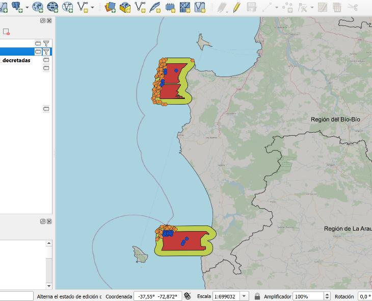

**50.** Estiliza las otras capas de contexto. Recomendaciones:

- **ECMPO_reproyectada:**
  - Color de borde: negro/blanco
  - Relleno: gris-azulado (distinto del océano del mapa base)
- **anillo_externo_ecmpo (decretadas):**
  - Borde: celeste claro, sin relleno o muy tenue
- Si decides incluir un shape de las regiones del país (utilizado en clases anteriores):
  - Color: gris claro
  - Usa simbología simple

**51.** Recuerda apagar temporalmente las otras capas y puedes ir a **“Nueva composición de impresión”** a confeccionar el diseño final de tu mapa como hemos aprendido en clases anteriores.

**Nota**

**PAUSA** — debería verse así:

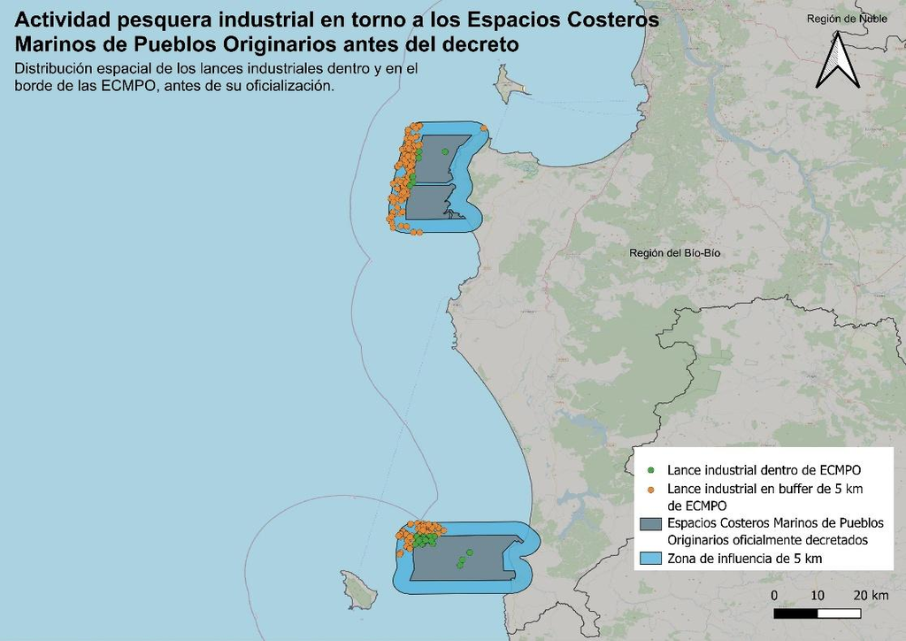

Mapa 1 terminado: actividad pesquera industrial en torno a los ECMPO *antes* del decreto, con leyenda y escala.

## Paso 16 | Mapa 2 — Actividad pesquera *después* del decreto

**Mapa 2** — Este mapa muestra los lances ocurridos **una vez decretada la ECMPO**, y permite ver **si cambió la intensidad o localización de los lances** respecto al área protegida.

**52.** En ambas capas `Lances_dentro_ECMPO` y `lances_borde_ecmpo`, ve a **Propiedad → Duplicar capa**.

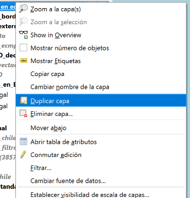

Duplicar capa desde el menú contextual.

**53.** En las nuevas capas, repite los pasos N°47 y N°48, pero con la siguiente expresión en el **Constructor de consultas**:

```
"periodo" = 'Después'
```

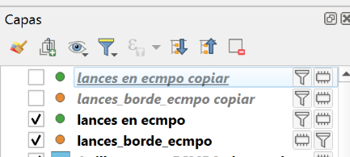

Panel de capas con las duplicadas filtradas por periodo = ‘Después’.

**54.** Mantén los **mismos colores** en todas las capas para que la comparación sea más efectiva.

**55.** Recuerda apagar temporalmente las otras capas y puedes ir a **“Nueva composición de impresión”** a confeccionar el diseño final de tu mapa como hemos aprendido en clases anteriores.

**Nota**

**PAUSA** — debería verse así:

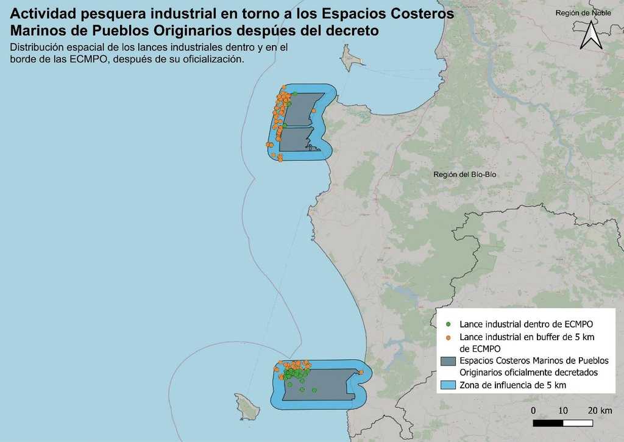

Mapa 2 terminado: actividad pesquera industrial en torno a los ECMPO *después* del decreto.

## ¡Listo!

Has finalizado tus mapas y ejercicios. **Recuerda completar esta actividad y guardar tu carpeta para utilizarla en tu próximo portafolio.**

**Importante**

**Elige uno o varios ECMPO de interés para tu portafolio.** Considera las siguientes preguntas guía:

1. ¿Qué implicancias tiene que un lance ocurra **después del decreto** de una ECMPO y **dentro** de su área protegida? ¿Podemos inferir automáticamente que hubo incumplimiento?
2. ¿Cómo **cambia tu percepción del territorio** cuando representas espacialmente la relación entre pesca industrial y espacios indígenas?
3. ¿Cómo se relaciona este análisis con conceptos más amplios como la **justicia ambiental** y la **gobernanza marina**?